# Lab 8: Central limit theorem & confidence intervals

# 1 Central limit theorem

The central limit theorem states that given a large enough sample size $n$, the sampling distribution of the mean will approach normal regardless of the shape of the distribution of the population values. Even if the population values are skewed, if you sample them repeatedly, the distribution of the sample means is approximately normal. This might not sound like a big deal, but it’s part of why we can use statistics to infer properties about the population from the sample! As $n$ increases, the sampling distribution of the mean converges to a normal distribution where the mean equals the population mean and the standard deviation equals the population standard deviation divided by the square root of $n$. This standard deviation of the sample means is known as the **standard error of the mean**:
$$\bar{x}\sim{N(mean=\mu,SE=\frac{\sigma}{\sqrt{n}})}$$
This equation reads, the mean of x ($\bar{x}$) is distributed normally ($\sim{N}$) with a mean that equals the population mean ($\mu$) and a standard error ($SE$) that equals the population standard deviation ($\sigma$) over the square root of the sample size ($\sqrt{n}$). Let’s make some plots to see what this means.

First, let’s create a population that we will sample from and make a quick histogram to see what its characteristics.

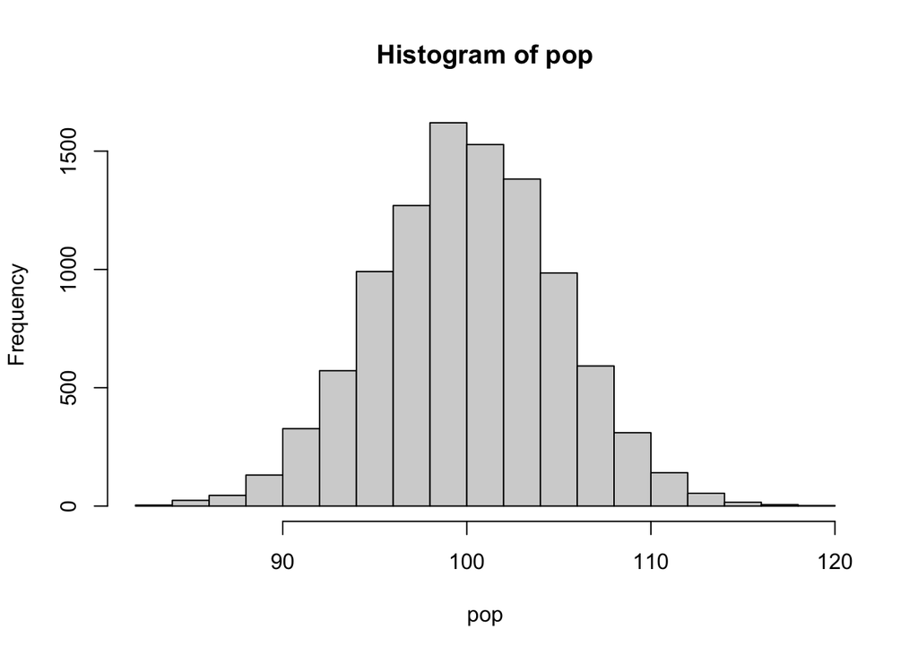

```r
set.seed(1234)

pop <- rnorm(10000, mean = 100, sd = 5)
pop.mean <- mean(pop)

hist(pop)
```

Let’s take some samples from the population using different sample sizes and take the mean of each sample. Then we will plot them over the histogram and zoom in so we can take a look. We will also add a vertical line for the true population mean to see how the sample means compare.

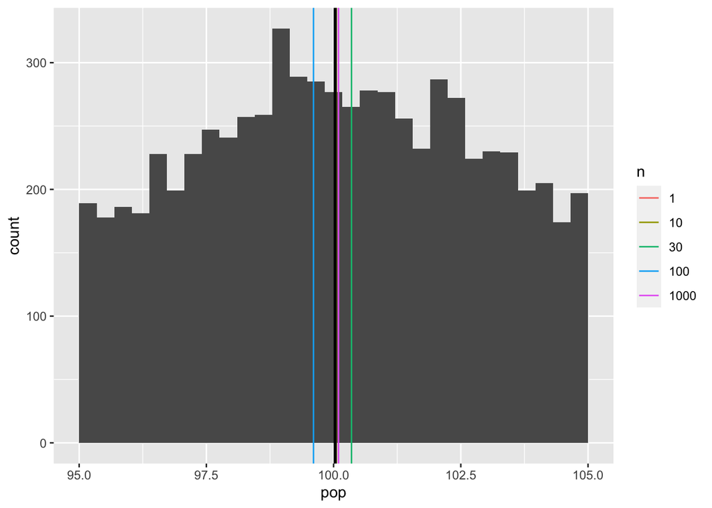

```r
set.seed(1234)
samps <- tibble(n = c(1, 10, 30, 100, 1000)) %>%
  rowwise() %>%
  mutate(mean = mean(sample(pop, size = n)),
         n = as.factor(n))

ggplot() +
  geom_histogram(aes(pop)) +
  geom_vline(data = samps, aes(xintercept = mean, color = n), key_glyph = "path") +
  geom_vline(xintercept = pop.mean, size = 1) +
  xlim(95, 105)
```

tests like t-tests on non-normally distributed data. This is because the distributions of the means will be normally distributed.

Let’s go through that again but with some non-normally distributed data.

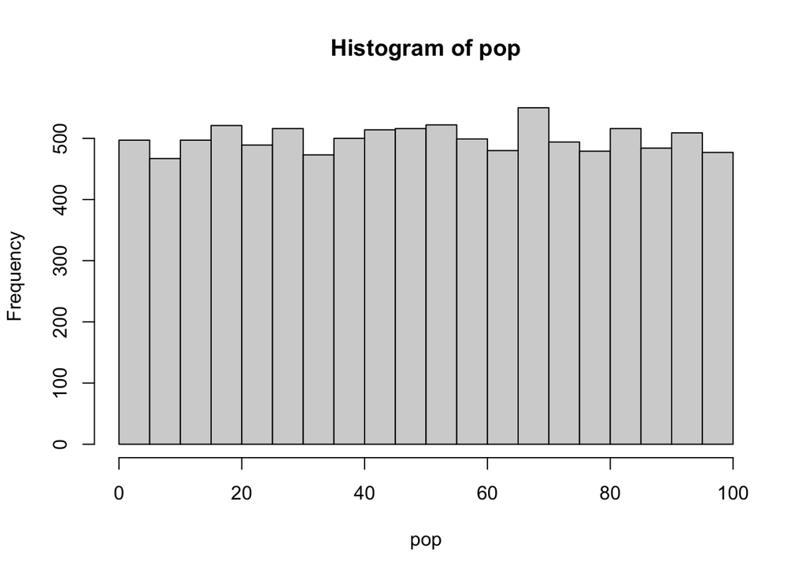

```r
set.seed(1234)

pop <- runif(10000, min = 0, max = 100)
pop.mean <- mean(pop)

hist(pop)
```

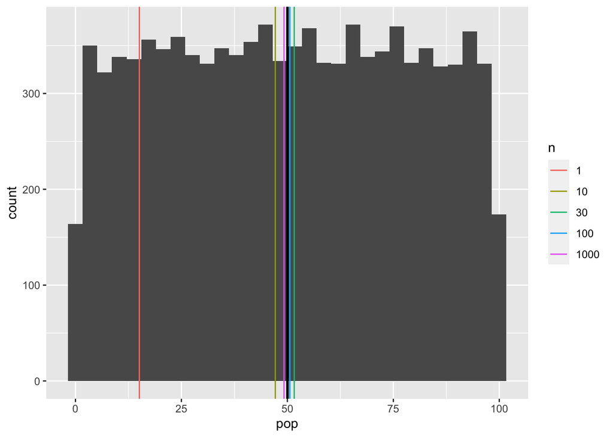

```r
set.seed(1234)
samps <- tibble(n = c(1, 10, 30, 100, 1000)) %>%
  rowwise() %>%
  mutate(mean = mean(sample(pop, size = n)),
         n = as.factor(n))

ggplot() +
  geom_histogram(aes(pop)) +
  geom_vline(data = samps, aes(xintercept = mean, color = n), key_glyph = "path") +
  geom_vline(xintercept = pop.mean, size = 1)
```

Again, you can see that the larger the sample size, the closer the sample mean is to the population mean.

Now let’s look at the distribution of those sample means. We’ll take more samples so that we can get a smoother distribution. You can see that the sample means are normally distributed even though the population is not and that the sample means are centered on the population mean.

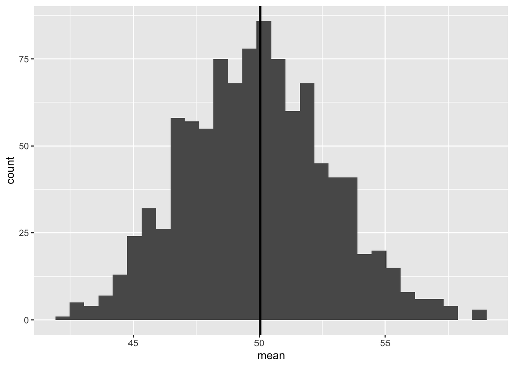

```r
set.seed(1234)
samps <- tibble(trial = 1:1000) %>%
  rowwise() %>%
  mutate(mean = mean(sample(pop, size = 100)))

ggplot() +
  geom_histogram(data = samps, aes(mean)) +
  geom_vline(xintercept = pop.mean, size = 1)
```

# 2 Confidence intervals

Confidence intervals represent the range of values that can be confidently expected to contain the true value of a parameter. You’ll recall that statistics are calculated for samples and parameters for population. Confidence intervals express how sure we are that our sample statistic is representative of the true population parameter. Here’s a [nice explanatory video](https://www.youtube.com/watch?v=tFWsuO9f74o&feature=youtu.be&ab_channel=DrNic%27sMathsandStats).

The confidence interval for the mean when you do not know the population standard deviation—which is pretty much always—and the sample size is large—above 30—is calculated as:
$$\bar{X}\pm{z^*\frac{s}{\sqrt{n}}}$$
where $\bar{X}$ is the sample mean, $\pm{z^*}$ is the critical z-value for a given confidence level, $s$ is the sample standard deviation, and $n$ is the sample size. Even if the distribution of the data is not normal, if the sample size is large, the central limit theorem takes effect and we can use $z^*$ which is a theoretical normal distribution. If the sample size is small, $t^*$ from the t-distribution needs to be used (Fig. 2.1). Using the t-distribution will always provide a more conservative estimate, meaning that your confidence interval will be wider.

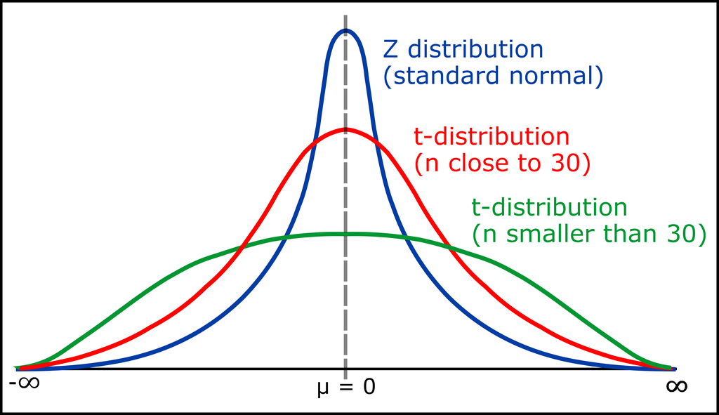

Figure 2.1: The t-distribution has a higher variance than the z-distribution and is appropriate for smaller datasets. Image taken from: https://www.geeksforgeeks.org/

Let’s sample our population again and calculate a 95% confidence interval for the sample mean. We will use the `qnorm()` function to calculate the critical value $z^*$. Because the `qnorm()` function returns a one-sided value, the input quantile for a 95% confidence interval is 0.975. In other words, we are interested in finding the critical value that will contain all the values between the lowest 2.5% and the highest 2.5% of the data. Of course we’ll plot it too.

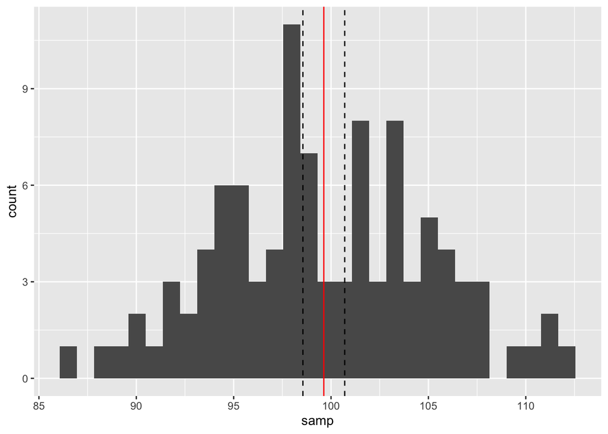

```r
set.seed(1234)

pop <- rnorm(10000, mean = 100, sd = 5)
pop.mean <- mean(pop)

n <- 100
set.seed(1234)
samp <- sample(pop, size = n)
samp.mean <- mean(samp)

zcrit <- qnorm(0.975)
std.dev <- sd(samp)

ci.lower <- samp.mean - zcrit * (std.dev / sqrt(n))
ci.upper <- samp.mean + zcrit * (std.dev / sqrt(n))

ggplot() +
  geom_histogram(aes(samp)) +
  geom_vline(xintercept = samp.mean, color = "red") +
  geom_vline(xintercept = ci.lower, linetype = 2) +
  geom_vline(xintercept = ci.upper, linetype = 2)
```

You can also have the `t.test()` function calculate the interval for you. The default is calculated using a 95% confidence interval. To change it you just specify `conf.level = 0.99` or whichever level you like in the function. The `t.test()` always uses a t-distribution.

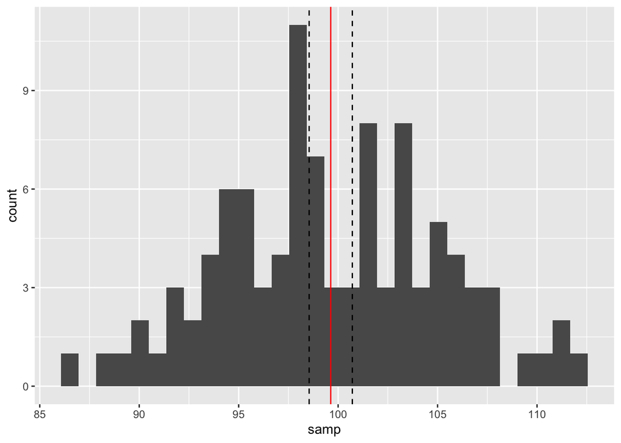

```r
set.seed(1234)

pop <- rnorm(10000, mean = 100, sd = 5)

n <- 100
set.seed(1234)
samp <- sample(pop, size = n)
samp.mean <- mean(samp)

# We can access parts of the t-test outcome because it returns a list.
# Here we are extracting the upper and lower confidence interval bounds
# and saving them as variables.

ci.lower2 <- t.test(samp)$conf.int[1]
ci.upper2 <- t.test(samp)$conf.int[2]

ggplot() +
  geom_histogram(aes(samp)) +
  geom_vline(xintercept = samp.mean, color = "red") +
  geom_vline(xintercept = ci.lower2, linetype = 2) +
  geom_vline(xintercept = ci.upper2, linetype = 2)
```

If you compare the upper and lower bounds from the two methods you will see that the confidence interval provided by `t.test()` is ever so slightly larger than using the z-distribution. As the sample size increases, this difference will lessen. It is already small enough that it doesn’t really change the interpretation of the estimate.

We’ll make a plot of some confidence intervals to illustrate the idea. We’ll draw 100 samples from a population and get the confidence interval of the mean for each. Then we will plot them with the true mean of the population.

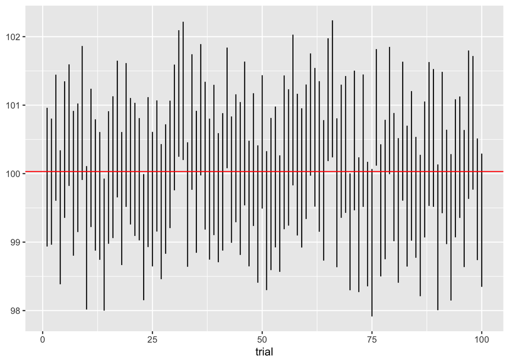

```r
set.seed(1234)

pop <- rnorm(10000, mean = 100, sd = 5)
pop.mean <- mean(pop)

# This code creates 100 rows, then a column that contains a list of the sampled values.
# Then it creates a column for the lower bound of the confidence interval and one for
# the upper bound and extracts those values from the one sample t-test

samps <- tibble(trial = 1:100) %>%
  rowwise() %>%
  mutate(samp = list(sample(pop, size = 100)),
         ci.low = t.test(samp)$conf.int[1],
         ci.upp = t.test(samp)$conf.int[2])

# To calculate the 99% confidence interval you would change t.test(samp) to
# t.test(samp, conf.level = 0.99).

ggplot(samps) +
  geom_linerange(aes(x = trial, ymin = ci.low, ymax = ci.upp, group = trial)) +
  geom_hline(yintercept = pop.mean, color = "red")
```

The red line is the true population mean. You can see that the confidence intervals contain the true mean most of the time. In fact, 92 of the 100 samples produce confidence intervals that contain the true mean. While that does not exactly equal 95%, it’s pretty close and if we increase the number of samples or the number of observations in each sample it would get even closer. That’s why large sample sizes are so important! The give a more precise estimation of parameters.

# 3 Exercises

1. Create a population of `n = 10000` from an exponential distribution. Use the function `rexp()`. The only argument that you need to specify is `n`. If you need help, type the function into the Help search bar on the lower right panel. Create a histogram using `ggplot()` that includes a vertical line showing the population mean, save it, and submit it to BB along with your script. Refer to past labs if you need help doing this.
2. Create three samples from your population—a sample of 50, a sample of 100, and a sample of 5000.
3. For each of the samples calculate the sample mean and the confidence interval of the mean. Use whichever method you like for calculating the confidence intervals. You will want to use different variable names for each so that you are not saving over variables that you need.
4. For each of the samples, create a histogram of the sample that shows:
- a vertical line for the population mean in a color
- a vertical line for the sample mean in black
- two dashed vertical lines for the confidence interval. Make sure to give your plot meaningful titles that give the number of trials. Save each plot and submit it to BB.
5. Describe what happens to sample means and the confidence intervals as the number of trials increase.